# DataCleaning

Lu-K Gautier

2022-11-09

This script is the data cleaning script for the project “Threat and Controllability” that study the impact of the controllability of a threat on attention processes. It use a spatial cueing paradigm.

The OSf link of this project is available at: https://osf.io/ynuc2/

```r
knitr::knit_hooks$set(
   error = function(x, options) {
     paste('\n\n<div class="alert alert-danger">',
           gsub('##', '\n', gsub('^##\ Error', '**Error**', x)),
           '</div>', sep = '\n')
   },
   warning = function(x, options) {
     paste('\n\n<div class="alert alert-warning">',
           gsub('##', '\n', gsub('^##\ Warning:', '**Warning**', x)),
           '</div>', sep = '\n')
   },
   message = function(x, options) {
     paste('\n\n<div class="alert alert-info">',
           gsub('##', '\n', x),
           '</div>', sep = '\n')
   }
)
```

# Aim of the script :

Open and prepare data from the ThreatControllability project to run analysis.

# Build the dataframe

## Experiment dataframe

### Open files

```r
# Create a file containing each file name present in the folder
Filelist <- list.files(path = "Data/experiment_data/")
# Give the number of file in the folder (it's also the number of participants)
Nb_Ppt<- length(Filelist)

List = list() # Create an empty list
df <- data.frame() # Create an empty dataframe

# A loop for open all the particpant data in a unique dataframe
for (i in Filelist) {
  no_col <- max(count.fields(paste("Data/experiment_data/",i, sep = ""), sep = " ")) # Count the number of column in each datafile

  tmp<- read.table(paste("Data/experiment_data/",i, sep = ""),sep=" ",fill=TRUE,header = F,col.names=c(1:no_col)) # Read the datafile

  tmp$Ppt <- i # Add the name of the participant to the dataframe
  tmp$response_id <- length(List)+1 # Add the participant ID to the dataframe

  df<- rbind(df,tmp) # Add the last file read to the final dataframe
  List[[length(List)+1]] = i # Inncrease the participant ID for reading the next file
}

# Transform participant ID in a factor
df$response_id <- factor(df$response_id)
# Give the number of participant
Nb_level<- nlevels(df$response_id)

# Is the number of participants in the final dataframe match the original number of files
ifelse(identical(Nb_Ppt,Nb_level)==TRUE, ("The number of participants in the final dataframe match the number of files"),("Warning: The number of participants do not match the number of files"))
```

```
## [1] "The number of participants in the final dataframe match the number of files"
```

```r
rm(list=setdiff(ls(), c("df"))) # clear workspace except the data frame
```

The total number of participants before exclusion is N = 258

###Rename variables

Experiment CodeBook

- Ppt_Response_Nb: The response given by the participant in terms of number (1=g, 2=b, 3=h, 4=y)
- Ppt_Response: The response given by the participant (g, b, h or y) in the location task
- Catego_Key_Response: the theoretical correct response key for the same task with a

categorization instruction (b or n)

- Key_Response_Nb: The correct response for the localization task in terms of number (1=g, 2=b, 3=h, 4=y)
- Response_Status: Participant Response status : 1=Correct answer, 2=Wrong answer, 3=No response (>1500ms)
- Target_Position: The localisation of the target positition (left, right, top, bottom)
- Target_Type: Which target the participants should respond to (X or =). The target type is randomly assign for each trial (within-subject)
- Target_Color: The color of the target participants should response to. This color is assign to participants (between-subject) during instructions and stay the same during all the task
- Cueing_Status: Trial type in terms of cueing validity. Same = Cue and target appear at the same localization ; Different = Cue and target appear at different localizations ; NoLocation = No cue validity since all cues are white
- Cueing_Validity: Rename “Cueing_Status” to match the cueing validity standards (Valid, Invalid or NoValidity)
- Cue_Position: The position of the cue (left, bottom, right, top or NoCue)
- Cue_Color: Color of the cue (red, green or white)
- Congruency: Congruency (in terms of color) between cue and target. Congruent = same color between target and cue ; Incongruent = Different colors between target and cue ; NoCongruency = No congruency because all cues are white
- RT: Response time for each trial
- Blockname: Name of the block the participant is completing :
  - Training_Red/Training_Green: Training block = 20 trials of practice
  - Control_Red/Control_Green: Control block = the spatial cueing task in its original conceptualisation (144 trials)
  - TrialXRedThreat/TrialXGreenThreat: Threat block = the spatial cueing task in which participants hear screams during the task (144 trials)
  - TrialXRedToon/TrialXGreenToon: Toon block = the spatial cueing task in which participants hear vocalizations during the task (144 trials) In these three blocks of trials, the distribution of trials is as follows: - No-Congruency = 48 - Congruent Valid = 12 - Congruent Invalid = 36 - Incongruent Valid = 12 - Incongruent Invalid = 36
  - ScaleControl: Anxiety ratings after the control block
  - ScaleThreat: Anxiety ratings after the Threat block
  - ScaleToon: Anxiety ratings after the Toon block
  - TrialScream: A screams happens
  - TrialToon: A vocalization happens
- Taskname: The name of the task completed by the participant for this specific trial
- Order: The order of task completion. In this specific experiment all participants are exposed to the “Threat then Toon” Blockorder. 1 = ControlRed then ThreatRed then ToonRed Blocks ; 2 = ControlGreen then ThreatGreen then ToonGreen Blocks
- Blockorder: The order of task completion (ThreatFirst_Red or ThreatFirst_Green)
- SOA: Duration between the fixation point and the cue happening in ms (1000ms, 1100ms, 1200ms, 1300ms, 1400ms)
- Sound_Nb: The sound number that the participant hear.
  - 3 = ExpF1
  - 4 = ExpF2
  - 5 = ExpF3
  - 6 = ExpM1
  - 7 = ExpM2
  - 8 = ExpM3
  - 9 = TOON1 (VocF1)
  - 10 = TOON2 (VocF2)
  - 11 = TOON3 (VocF3)
  - 12 = TOON4 (VocM1)
  - 13 = TOON5 (VocM2)
  - 14 = TOON6 (VocM3)
- Sound_Name: The sound name that the participant hear
- Sound: The sound that the participant hear (ExpF1, ExpF2, ExpF3, ExpM1, ExpM2, ExpM3, VocF1, VocF2, VocF3, VocM1, VocM2 or VocM3)

`warning("I may have forgotten some variables I built in this codebook. I have t ckeck the final data frame to see if there is no missing variable !!!")`

```r
tmp <- df # Create a temporary file based on df

names(tmp)[1] <- "Ppt_Response_Nb"
tmp <- tmp %>% mutate(Ppt_Response_Nb = replace(Ppt_Response_Nb, X4 == 3, "NoResponse"))

tmp <- tmp %>% mutate(Ppt_Response = case_when(Ppt_Response_Nb == 1 & X4 != 3 ~ "g",
                                               Ppt_Response_Nb == 2 & X4 != 3 ~ "b",
                                               Ppt_Response_Nb == 3 & X4 != 3 ~ "h",
                                               Ppt_Response_Nb == 4 & X4 != 3 ~ "y",
                                               X4 == 3 ~ "NoResponse"))

warning("If participant didn't give a response during the response time window (<1500ms), we assign Ppt_Response to 'NoResponse'. It's the same for the variable Ppt_Response_Nb")
```

**Warning** If participant didn’t give a response during the response time window

(<1500ms), we assign Ppt_Response to ‘NoResponse’. It’s the same for the

variable Ppt_Response_Nb

```r
warning("We have to remove trials wher participants didn't give answers to th location task")
```

**Warning** We have to remove trials wher participants didn’t give answers to th

location task

```r
names(tmp)[2] <- "Catego_Key_Response"
names(tmp)[3] <- "Key_Response_Nb"
names(tmp)[4] <- "Response_Status"
names(tmp)[5] <- "Target_Position"
names(tmp)[6] <- "Target_Type"
names(tmp)[7] <- "Target_Color"

names(tmp)[8] <- "Cueing_Status"
tmp <- tmp %>% mutate(Cueing_Validity = case_when(Cueing_Status == "Same" ~ "Valid",
                                                  Cueing_Status == "Different" ~ "Invalid",
                                                  Cueing_Status == "NoLocation" ~ "NoValidity"))

names(tmp)[9] <- "Cue_Position"
names(tmp)[10] <- "Cue_Color"
names(tmp)[11] <- "Congruency"
names(tmp)[12] <- "RT"
names(tmp)[13] <- "Blockname"

tmp <- tmp %>% mutate(Block = case_when(Blockname == "Training_Red" ~ "Training",
                                        Blockname == "Training_Green" ~ "Training",
                                        Blockname == "Control_Red" ~ "Control",
                                        Blockname == "Control_Green" ~ "Control",
                                        grepl('^Trial', Blockname)&grepl('Threat', Blockname) ~ "Threat",
                                        grepl('^Trial', Blockname)&grepl('Scream', Blockname) ~ "Scream",
                                        grepl('^Trial', Blockname)&(grepl('RedToon', Blockname)|grepl('GreenToon', Blockname)) ~ "Toon",
                                        grepl('TrialToon', Blockname) ~ "Vocalization",
                                        Blockname == "ScaleControl" ~ "Scale",
                                        Blockname == "ScaleThreat" ~ "Scale",
                                        Blockname == "ScaleToon" ~ "Scale"))

TrialDistrib <- table(tmp$Block) # create a table with the total number of trials of each type
TrialNumber <- TrialDistrib/258  # create a table with the number of trials of each type per participant
Nb_Ppt<-nlevels(df$response_id) # Calculate the total number of participants
x <- c(1:7)

# Give the number of trials for each type of trials and the total number of trials in the overall sample
for (i in x) {
  Text<- paste("Le total des essais dans le block", names(TrialDistrib)[[i]], "pour n =", Nb_Ppt, "participant.e.s effectuant", TrialNumber[[i]], "essais est", TrialDistrib[[i]])
  print(Text)
}
```

```
## [1] "Le total des essais dans le block Control pour n = 258 participant.e.s effectuant 144 essais est 37152"
## [1] "Le total des essais dans le block Scale pour n = 258 participant.e.s effectuant 24 essais est 6192"
## [1] "Le total des essais dans le block Scream pour n = 258 participant.e.s effectuant 18 essais est 4644"
## [1] "Le total des essais dans le block Threat pour n = 258 participant.e.s effectuant 144 essais est 37152"
## [1] "Le total des essais dans le block Toon pour n = 258 participant.e.s effectuant 144 essais est 37152"
## [1] "Le total des essais dans le block Training pour n = 258 participant.e.s effectuant 20 essais est 5160"
## [1] "Le total des essais dans le block Vocalization pour n = 258 participant.e.s effectuant 18 essais est 4644"
```

```r
names(tmp)[14] <- "Taskname"
names(tmp)[15] <- "Order"
tmp <- tmp %>% mutate(Blockorder = case_when(Order == "1" ~ "ThreatFirst_Red",
                                             Order == "2" ~ "ThreatFirst_Green"))

names(tmp)[16] <- "SOA"
names(tmp)[17] <- "Task"

names(tmp)[18] <- "Emotion_Rating"
# tmp <- tmp %>% mutate(Emotion_Rating = replace(Emotion_Rating, Emotion_Rating == -1, "NoResponse"))

warning("Emotion_Rating is a 1 to 7 likert scale, but if participant didn't give a response during the response time window (<30s), Emotion_Rating is assigned to '-1'.")
```

**Warning** Emotion_Rating is a 1 to 7 likert scale, but if participant didn’t give

a response during the response time window (<30s), Emotion_Rating is assigned to

‘-1’.

```r
print(paste("There is", table(tmp$Emotion_Rating)[[1]], "cells that contain a -1 value in the overall set of responses on the anxiety scale"))
```

```
## [1] "There is 39 cells that contain a -1 value in the overall set of responses on the anxiety scale"
```

```r
names(tmp)[19] <- "Emotion_Type"
tmp <- tmp %>% mutate(Emotion = case_when(Emotion_Type == "Angoisse" ~ "Anxious",
                                          Emotion_Type == "Calme" ~ "Calm",
                                          grepl('^Col', Emotion_Type) ~ "Angry",
                                          Emotion_Type == "Deprime" ~ "Depressed",
                                          Emotion_Type == "Joie" ~ "Happy",
                                          Emotion_Type == "Nervosite" ~ "Nervous",
                                          Emotion_Type == "Stress" ~ "Stressed",
                                          Emotion_Type == "Tension" ~ "Tense",))


names(tmp)[20] <- "Sound_Nb"
names(tmp)[21] <- "Sound_Name"
tmp <- tmp %>% mutate(Sound = case_when(Sound_Nb == "3" ~ "ExpF1",
                                        Sound_Nb == "4" ~ "ExpF2",
                                        Sound_Nb == "5" ~ "ExpF3",
                                        Sound_Nb == "6" ~ "ExpM1",
                                        Sound_Nb == "7" ~ "ExpM2",
                                        Sound_Nb == "8" ~ "ExpM3",
                                        Sound_Nb == "9" ~ "VocF1",
                                        Sound_Nb == "10" ~ "VocF2",
                                        Sound_Nb == "11" ~ "VocF3",
                                        Sound_Nb == "12" ~ "VocM1",
                                        Sound_Nb == "13" ~ "VocM2",
                                        Sound_Nb == "14" ~ "VocM3",))

df <- tmp

rm(list=setdiff(ls(), c("df"))) # clear workspace except the data frame
```

### Calculate Anxiety score

#### Converting rows in columns

```r
tmp <- df

#Fear <- filter(tmp, !is.na(tmp$Emotion_Rating)) ## Create a dataframe which only contains participant ratings on emotions

# Create a data frame converting emotion ratings in column instead of rows
## For the different block (Control, Threat, Toon) at the same time

# Create a dataframe that contain only emotion rating  trials
dt_Emotion <- tmp %>% filter(grepl(pattern =  "Scale", Blockname))

# Convert the Emotion_Type variable into different columns associated to each emotion (= Add a column to each Emotion)
dt_Emotion <- dt_Emotion %>%
  group_by(Emotion, Blockname) %>%
  mutate(id = response_id) %>%
  pivot_wider(
    names_from = c(Emotion),
    values_from = c(Emotion_Rating)
  )

# Select only variables that are relevant for calculating the Anxiety score
dt_Emotion <- select(dt_Emotion, Blockname, Taskname, Task, response_id, Block, Angry, Calm, Anxious, Nervous, Happy, Tense, Stressed, Depressed)

# Make sure that anxiety variable have a numeric structure
dt_Emotion <- dt_Emotion %>% mutate_at(c("Angry", "Calm", "Anxious", "Nervous", "Happy", "Tense", "Stressed", "Depressed"), as.numeric)

# Combine the 8 rows of anxiety score for each participant/block into one row
dt_Emotion <- dt_Emotion %>%
   group_by(Blockname, Taskname, Task, response_id, Block) %>%
   summarize_all(sum, na.rm = TRUE)

# Replace the -1 values on anxiety ratings (=no response in the response time window (<30s)) by Na values
dt2_Emotion <- dt_Emotion %>%
  mutate(Angry= na_if(Angry,-1),
         Calm= na_if(Calm,-1),
         Anxious= na_if(Anxious,-1),
         Nervous= na_if(Nervous, -1),
         Happy= na_if(Happy,-1),
         Tense= na_if(Tense,-1),
         Stressed= na_if(Stressed,-1),
         Depressed= na_if(Depressed,-1))

NA_Num <- colSums((dt_Emotion)==-1) # the number of '-1' values (=no response on the ratings) in the 1rst dataframe
NA_Replace <- colSums(is.na(dt2_Emotion)) # the number of NA (=no response on the ratings) that replace the '-1' value in the 2nd dataframe
x <- c(6:13) # Create a list of emotions

# Check if there is a mismatch between the number of no response on ratings before and after replacing the '-1' values by NA
for (i in x) {
  ifelse(near(NA_Num[[i]], NA_Replace[[i]])==TRUE,
         print(paste("The number of NA after replacement fit the number of '-1' values (=no response on the rating for the emotion:", names(NA_Num)[[i]])),
         print(paste("Warning: The number of NA after replacement doesn't fit the number of '-1' values (=no response on the rating for the emotion:", names(NA_Num)[[i]])))
}
```

```
## [1] "The number of NA after replacement fit the number of '-1' values (=no response on the rating for the emotion: Angry"
## [1] "The number of NA after replacement fit the number of '-1' values (=no response on the rating for the emotion: Calm"
## [1] "The number of NA after replacement fit the number of '-1' values (=no response on the rating for the emotion: Anxious"
## [1] "The number of NA after replacement fit the number of '-1' values (=no response on the rating for the emotion: Nervous"
## [1] "The number of NA after replacement fit the number of '-1' values (=no response on the rating for the emotion: Happy"
## [1] "The number of NA after replacement fit the number of '-1' values (=no response on the rating for the emotion: Tense"
## [1] "The number of NA after replacement fit the number of '-1' values (=no response on the rating for the emotion: Stressed"
## [1] "The number of NA after replacement fit the number of '-1' values (=no response on the rating for the emotion: Depressed"
```

```r
dt_Emotion <- dt2_Emotion
print(paste("The total number of NA values on emotion ratings is", sum(is.na(dt_Emotion))))
```

```
## [1] "The total number of NA values on emotion ratings is 39"
```

```r
rm(i,x, NA_Num,NA_Replace, dt2_Emotion)
```

#### Imputating Missing Values

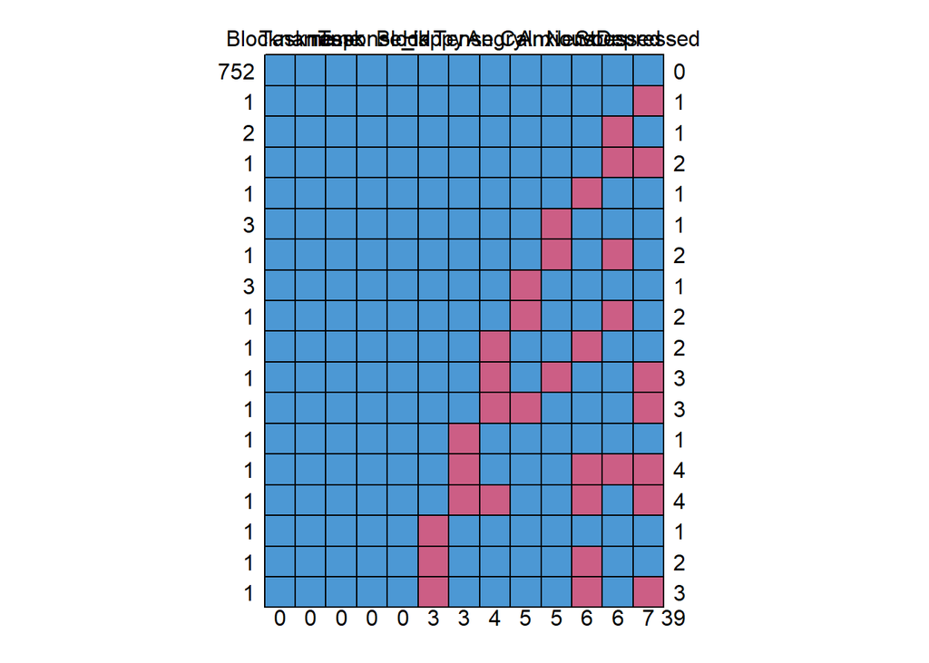

```
##     Blockname Taskname Task response_id Block Happy Tense Angry Calm Anxious
## 752         1        1    1           1     1     1     1     1    1       1
## 1           1        1    1           1     1     1     1     1    1       1
## 2           1        1    1           1     1     1     1     1    1       1
## 1           1        1    1           1     1     1     1     1    1       1
## 1           1        1    1           1     1     1     1     1    1       1
## 3           1        1    1           1     1     1     1     1    1       0
## 1           1        1    1           1     1     1     1     1    1       0
## 3           1        1    1           1     1     1     1     1    0       1
## 1           1        1    1           1     1     1     1     1    0       1
## 1           1        1    1           1     1     1     1     0    1       1
## 1           1        1    1           1     1     1     1     0    1       0
## 1           1        1    1           1     1     1     1     0    0       1
## 1           1        1    1           1     1     1     0     1    1       1
## 1           1        1    1           1     1     1     0     1    1       1
```

[output cut: 25 more lines]

```r
md.pattern(dt_Emotion) # To get the missing pattern on the different variables
```

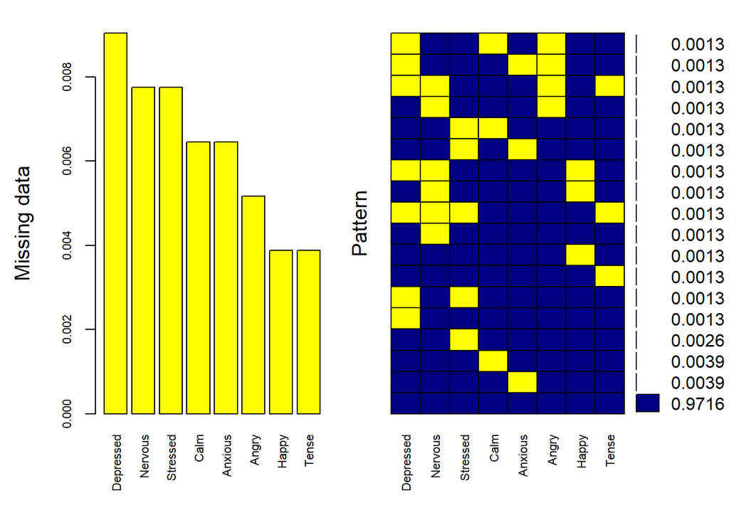

```
##
##  Variables sorted by number of missings:
##   Variable       Count
##  Depressed 0.009043928
##    Nervous 0.007751938
##   Stressed 0.007751938
##       Calm 0.006459948
##    Anxious 0.006459948
##      Angry 0.005167959
##      Happy 0.003875969
##      Tense 0.003875969
```

```r
# An other way to represent this pattern of missing values
mice_plot <- aggr(dt_Emotion[,6:13], col=c('navyblue','yellow'),
                  numbers=TRUE, sortVars=TRUE,
                  labels=names(dt_Emotion[,6:13]), cex.axis=.7,
                  gap=3, ylab=c("Missing data","Pattern"))
```

```r
# Ungroup the dataframe
dt_Emotion <- dt_Emotion %>%
  ungroup()

# To use the missForest function, dt_Emotion must be a dataframe and
dt_Emotion<- as.data.frame(dt_Emotion)
dt_imputed <- missForest::missForest(dt_Emotion[c(6:13)], maxiter =10, ntree = 100)

Anxiety_Scale  <- dt_Emotion
Anxiety_Scale  <- dt_Emotion %>%
  mutate(dt_imputed$ximp)
sum(is.na(Anxiety_Scale ))
```

```
## [1] 0
```

```r
warning(paste0("Here, We imputed values on the anxiety scale for missing values using the overall dataset. However, we may have to impute values in each specific block and not with an overall imputation because we could make the prediction that the link between all these anxiety items is not the same within each block. Nevertheless it could be a minimal consideration given that the total amount of imputed data is ", sum(is.na(dt_Emotion)), " over a total number of ", (nrow(dt_Emotion) * 8), " anxiety answers: Number of participants (N = ", (nrow(dt_Emotion)/3), ") * 3 blocks * 8 anxiety measures" ))
```

**Warning** Here, We imputed values on the anxiety scale for missing values using

the overall dataset. However, we may have to impute values in each specific

block and not with an overall imputation because we could make the prediction

that the link between all these anxiety items is not the same within each block.

Nevertheless it could be a minimal consideration given that the total amount

of imputed data is 39 over a total number of 6192 anxiety answers: Number of

participants (N = 258) * 3 blocks * 8 anxiety measures

```r
warning("In this chunk, participant non-responses (= -1) have been replaced by missing values (NA).")
```

**Warning** In this chunk, participant non-responses (= -1) have been replaced by

missing values (NA).

```r
# Reverse the calm item
Anxiety_Scale <- Anxiety_Scale %>% mutate(Calm_Recod = (8-Calm))

# Associate each participant row to its block
Anxiety_Scale <- Anxiety_Scale %>% mutate(Block = case_when(Blockname == "ScaleControl" ~ "Control",
                                                            Blockname == "ScaleThreat" ~ "Threat",
                                                            Blockname == "ScaleToon" ~ "Toon"))


rm(list=setdiff(ls(), c("df","Anxiety_Scale"))) # clear workspace except the data frame and the "Anxiety_Scale" dataframe
```

#### Calculation of a factorial score

Here we want to calculate a factorial score for each participant and for each block based on the five items of anxiety feelings during the experiment

```r
tmp <- na.omit(Anxiety_Scale)
warning("Here, we have removed rows with NA beacause it's a prerequisite for factor analysis. However, given that we previously imputed mussing values on this anxiety measure, we don't have any NA to remove. ")
```

**Warning** Here, we have removed rows with NA beacause it’s a prerequisite for

factor analysis. However, given that we previously imputed mussing values on

this anxiety measure, we don’t have any NA to remove.

```r
# Check if it is possible to agregate theses five measure (anxious, nervous, calm, tense, stressed) in an unique factor :
dt1_Factor<- tmp %>%
  select(Angry, Calm_Recod, Anxious, Nervous, Happy, Tense, Stressed, Depressed)

EFA_dt1 <- factanal(dt1_Factor, factors=2, rotation = "promax") # Promax = Oblique rotation
print(EFA_dt1, digits = 2, cutoff = .3)
```

```
##
## Call:
## factanal(x = dt1_Factor, factors = 2, rotation = "promax")
##
## Uniquenesses:
##      Angry Calm_Recod    Anxious    Nervous      Happy      Tense   Stressed
##       0.73       0.42       0.23       0.20       0.65       0.35       0.22
##  Depressed
##       0.90
##
## Loadings:
##            Factor1 Factor2
## Angry       0.37
## Calm_Recod          0.73
## Anxious     0.89
## Nervous     0.88
## Happy              -0.65
## Tense       0.73
## Stressed    0.92
## Depressed   0.35
##
##                Factor1 Factor2
## SS loadings       3.23    1.04
## Proportion Var    0.40    0.13
## Cumulative Var    0.40    0.53
##
## Factor Correlations:
##         Factor1 Factor2
## Factor1    1.00   -0.45
## Factor2   -0.45    1.00
##
## Test of the hypothesis that 2 factors are sufficient.
## The chi square statistic is 122.06 on 13 degrees of freedom.
## The p-value is 7.87e-20
```

```r
warning("Based on a factorial analysis on anxiety itmes, we couldn't agregate 'Calm' item to other anxiety items because this item don't load with the same factor.Moreover, despite items 'angry' and 'depressed' belong to the same factor as anxiety measurements, these 2 items have a lesser loading degree, so we decided not to agregate these items in our factorial score  according to our preregistration")
```

**Warning** Based on a factorial analysis on anxiety itmes, we couldn’t agregate

‘Calm’ item to other anxiety items because this item don’t load with the same

factor.Moreover, despite items ‘angry’ and ‘depressed’ belong to the same

factor as anxiety measurements, these 2 items have a lesser loading degree, so

we decided not to agregate these items in our factorial score according to our

preregistration

```r
# Some codes if we want to look if the factorial structure of this scale is the same between different blocks
dtCtrl_Factor1 <- tmp %>%
  filter(Block == "Control") %>%
  select(Angry, Calm_Recod, Anxious, Nervous, Happy, Tense, Stressed, Depressed)
EFA_dt1_Ctrl <- factanal(dtCtrl_Factor1, factors=2, rotation = "promax")

dtThreat_Factor1 <- tmp %>%
  filter(Block == "Threat") %>%
  select(Angry, Calm_Recod, Anxious, Nervous, Happy, Tense, Stressed, Depressed)
EFA_dt1_Threat <- factanal(dtThreat_Factor1, factors=2, rotation = "promax")

dtToon_Factor1 <-  tmp %>%
  filter(Block == "Toon") %>%
  select(Angry, Calm_Recod, Anxious, Nervous, Happy, Tense, Stressed, Depressed)
EFA_dt1_Toon <- factanal(dtToon_Factor1, factors=2, rotation = "promax")

print("Here is the factorial analysis on the anxiety scale for each specific block")
```

```
## [1] "Here is the factorial analysis on the anxiety scale for each specific block"
```

```r
print(EFA_dt1_Ctrl, digits = 2, cutoff = .3)
```

```
##
## Call:
## factanal(x = dtCtrl_Factor1, factors = 2, rotation = "promax")
##
## Uniquenesses:
##      Angry Calm_Recod    Anxious    Nervous      Happy      Tense   Stressed
##       0.68       0.33       0.38       0.34       0.64       0.45       0.27
##  Depressed
##       0.89
##
## Loadings:
##            Factor1 Factor2
## Angry       0.51
## Calm_Recod          0.78
## Anxious     0.78
## Nervous     0.80
## Happy              -0.62
## Tense       0.71
## Stressed    0.87
## Depressed   0.33
##
##                Factor1 Factor2
## SS loadings       2.93    1.06
## Proportion Var    0.37    0.13
## Cumulative Var    0.37    0.50
##
## Factor Correlations:
##         Factor1 Factor2
## Factor1    1.00   -0.25
## Factor2   -0.25    1.00
##
## Test of the hypothesis that 2 factors are sufficient.
## The chi square statistic is 31.99 on 13 degrees of freedom.
## The p-value is 0.00241
```

```r
print(EFA_dt1_Threat, digits = 2, cutoff = .3)
```

```
##
## Call:
## factanal(x = dtThreat_Factor1, factors = 2, rotation = "promax")
##
## Uniquenesses:
##      Angry Calm_Recod    Anxious    Nervous      Happy      Tense   Stressed
##       0.80       0.49       0.18       0.14       0.59       0.35       0.23
##  Depressed
##       0.91
##
## Loadings:
##            Factor1 Factor2
## Angry
## Calm_Recod          0.68
## Anxious     0.92
## Nervous     0.90
## Happy              -0.71
## Tense       0.67
## Stressed    0.92
## Depressed   0.33
##
##                Factor1 Factor2
## SS loadings       3.15    1.11
## Proportion Var    0.39    0.14
## Cumulative Var    0.39    0.53
##
## Factor Correlations:
##         Factor1 Factor2
## Factor1    1.00   -0.54
## Factor2   -0.54    1.00
##
## Test of the hypothesis that 2 factors are sufficient.
## The chi square statistic is 42.41 on 13 degrees of freedom.
## The p-value is 5.61e-05
```

```r
print(EFA_dt1_Toon, digits = 2, cutoff = .3)
```

```
##
## Call:
## factanal(x = dtToon_Factor1, factors = 2, rotation = "promax")
##
## Uniquenesses:
##      Angry Calm_Recod    Anxious    Nervous      Happy      Tense   Stressed
##       0.62       0.48       0.19       0.19       0.70       0.31       0.20
##  Depressed
##       0.84
##
## Loadings:
##            Factor1 Factor2
## Angry       0.37    0.35
## Calm_Recod          0.73
## Anxious     0.94
## Nervous     0.89
## Happy              -0.62
## Tense       0.73
## Stressed    0.93
## Depressed   0.39
##
##                Factor1 Factor2
## SS loadings       3.42    1.08
## Proportion Var    0.43    0.13
## Cumulative Var    0.43    0.56
##
## Factor Correlations:
##         Factor1 Factor2
## Factor1    1.00   -0.48
## Factor2   -0.48    1.00
##
## Test of the hypothesis that 2 factors are sufficient.
## The chi square statistic is 72.96 on 13 degrees of freedom.
## The p-value is 2.28e-10
```

```r
warning("In the threat block, the items 'Tense' seems to load to a lesser degree than other anxiety items.")
```

**Warning** In the threat block, the items ‘Tense’ seems to load to a lesser degree

than other anxiety items.

```r
# Compare fit indices in a CFA analysis on the 4 items of interest

# Define the CFA models for each block
model_General<- 'factor1 =~ Anxious + Nervous + Tense + Stressed'
model_ctrl <- 'factor1 =~ Anxious + Nervous + Tense + Stressed'
model_threat <- 'factor1 =~ Anxious + Nervous + Tense + Stressed'
model_toon <- 'factor1 =~ Anxious + Nervous + Tense + Stressed'

# For a factor that use all items:
#'factor1 =~ Angry + Calm_Recod + Anxious + Nervous + Happy + Tense + Stressed + Depressed'

# Fit the CFA models
fit_General <- cfa(model_General, data = dt1_Factor)
fit_ctrl <- cfa(model_ctrl, data = dtCtrl_Factor1)
fit_threat <- cfa(model_threat, data = dtThreat_Factor1)
fit_toon <- cfa(model_toon, data = dtToon_Factor1)

# Compare the model fit indices
fit_indices <- list (fitMeasures(fit_General, c("cfi", "rmsea", "srmr")), fitMeasures(fit_ctrl, c("cfi", "rmsea", "srmr")), fitMeasures(fit_threat, c("cfi", "rmsea", "srmr")), fitMeasures(fit_toon, c("cfi", "rmsea", "srmr")))

Table_fit_indices <- as.data.frame(fit_indices, col.names = list("Overall_Blocks", "Ctrl_Block", "Threat_Block", "Toon_Block"))
print(as.matrix(Table_fit_indices))
```

```
##       Overall_Blocks Ctrl_Block Threat_Block Toon_Block
## cfi       0.99021187 0.97689250  1.000000000 0.98143036
## rmsea     0.12086352 0.15208986  0.000000000 0.17431667
## srmr      0.01512203 0.02808242  0.004049913 0.02062012
```

```r
warning("Although there are some  variability in fit indices on these 3 CFA analysis using only the 4 anxiety items (Tense, Nervous, Anxious, Stressed), the model always show better indices (CFI, RMSEA, and SRMR) for the overall  dataset instead of separating each block individualy. Thus, we decided to calculate a factorial score for each participant  without taking in consideration a differential factorial structure of this anxiety scale within each block of trials.")
```

**Warning** Although there are some variability in fit indices on these 3 CFA

analysis using only the 4 anxiety items (Tense, Nervous, Anxious, Stressed),

calculate a factorial score for each participant without taking in consideration

a differential factorial structure of this anxiety scale within each block of

trials.

```r
## Calculate a factorial score from these 4 measure of stress
dt2_Factor <- tmp %>%
  select(Anxious, Nervous, Tense, Stressed)
FactorialScore <- fa(dt2_Factor, nfactors=1, rotate = "promax", scores = "Bartlett")

# Assign a threat score to each ppt calculated on the 4 measures of stress
tmp$Fear_Score<-FactorialScore$scores
tmp$Fear_Score <- as.numeric(tmp$Fear_Score)

# Calculating a mean rather than a factorial score
tmp <- tmp %>%
  mutate(Fear_Mean = rowMeans(select(tmp,c(Anxious, Nervous, Stressed, Tense))))

# Calculate the correlation between the factorial or the mean score of each participant on these 4 items
Cor_FactorMean <- cor.test(tmp$Fear_Score,tmp$Fear_Mean)

warning(paste0("According to our pre-registration, we calculate a factorial score on this anxiety scale for each participant. This type of data imputation to build a composite score on this scale seems quite similar to a Mean calulation since the correlation between between participant factorial score and participant mean is really high: r(", Cor_FactorMean[["parameter"]][["df"]],") = ", round(Cor_FactorMean[["estimate"]][["cor"]],3), " ; p-value = ", Cor_FactorMean[["p.value"]], "."))
```

**Warning** According to our pre-registration, we calculate a factorial score on

this anxiety scale for each participant. This type of data imputation to build a

composite score on this scale seems quite similar to a Mean calulation since the

correlation between between participant factorial score and participant mean is

really high: r(772) = 0.997 ; p-value = 0.

```r
Anxiety_Scale <- tmp

rm(list=setdiff(ls(), c("df","Anxiety_Scale"))) # clear workspace except the data frame and the "Anxiety_Scale" dataframe
```

Here, we have partially done with experiment data cleaning

## Questionnaire dataframe

### Rename variables

Survey CodeBook

```r
tmp2 <- data <- read_csv("Data/data.csv")
```

**Warning** One or more parsing issues, see `problems()` for details

Rows: 256 Columns: 48

– Column specification ——————————————————–

Delimiter: “,”

chr (5): participant, SpatialCueing_Controlability:1, SpatialCueing_Random:…

dbl (42): PTSD:1, PTSD:2, PTSD:3, PTSD:4, PTSD:5, PTSD:6, PTSD:7, PTSD:8, PT…

i Use `spec()` to retrieve the full column specification for this data.

i Specify the column types or set `show_col_types = FALSE` to quiet this message.

```r
#tmp2$Ppt <- NA
warning("j'ai pas encore pris le temps de faire le code book pour les variables que je suis en train de créer...!")
```

**Warning** j’ai pas encore pris le temps de faire le code book pour les variables

que je suis en train de créer…!

```r
names(tmp2)[1] <- "Participant"
names(tmp2)[2] <- "PTSD1"
names(tmp2)[3] <- "PTSD2"
names(tmp2)[4] <- "PTSD3"
names(tmp2)[5] <- "PTSD4"
names(tmp2)[6] <- "PTSD5"
names(tmp2)[7] <- "PTSD6"
names(tmp2)[8] <- "PTSD7"
names(tmp2)[9] <- "PTSD8"
names(tmp2)[10] <- "PTSD9"
names(tmp2)[11] <- "PTSD10"
names(tmp2)[12] <- "PTSD11"
names(tmp2)[13] <- "PTSD12"
names(tmp2)[14] <- "PTSD13"
names(tmp2)[15] <- "PTSD14"
names(tmp2)[16] <- "PTSD15"
names(tmp2)[17] <- "PTSD16"
names(tmp2)[18] <- "PTSD17"
names(tmp2)[19] <- "PTSD_Score"

# PTSD diagnostic in accordance to the threshold of 61 on a 1 to 5 point scale (or 44 on a 0 to 4 point scale)
tmp2 <- tmp2 %>% mutate(PTSD_Diag = case_when(PTSD_Score >= 61  ~ "Diag", PTSD1 <= 60 ~ "NoDiag"))


names(tmp2)[20] <- "Angry_pretest"
names(tmp2)[21] <- "Anxious_pretest"
names(tmp2)[22] <- "Happy_pretest"
names(tmp2)[23] <- "Depressed_pretest"
names(tmp2)[24] <- "Tense_pretest"
names(tmp2)[25] <- "Calm_pretest"
names(tmp2)[26] <- "Stressed_pretest"
names(tmp2)[27] <- "Nervous_pretest"


tmp2 <- tmp2 %>% mutate(Calm_Recod_Pretest = (8-Calm_pretest))

dt1_Factor<- na.omit(tmp2[,c(20:24,26:27, 50)])
EFA_dt1 <- factanal(dt1_Factor, factors=2, rotation = "promax") # Promax = Oblique rotation
print(EFA_dt1, digits = 2, cutoff = .3)
```

```
##
## Call:
## factanal(x = dt1_Factor, factors = 2, rotation = "promax")
##
## Uniquenesses:
##      Angry_pretest    Anxious_pretest      Happy_pretest  Depressed_pretest
##               0.66               0.25               0.21               0.51
##      Tense_pretest   Stressed_pretest    Nervous_pretest Calm_Recod_Pretest
##               0.29               0.28               0.30               0.59
##
## Loadings:
##                    Factor1 Factor2
## Angry_pretest       0.43
## Anxious_pretest     0.90
## Happy_pretest               1.02
## Depressed_pretest   0.42   -0.36
## Tense_pretest       0.88
## Stressed_pretest    0.95
## Nervous_pretest     0.85
## Calm_Recod_Pretest  0.51
##
##                Factor1 Factor2
## SS loadings       3.90    1.29
## Proportion Var    0.49    0.16
## Cumulative Var    0.49    0.65
##
## Factor Correlations:
##         Factor1 Factor2
## Factor1    1.00   -0.61
## Factor2   -0.61    1.00
##
## Test of the hypothesis that 2 factors are sufficient.
## The chi square statistic is 35.12 on 13 degrees of freedom.
## The p-value is 0.000811
```

```r
rm(dt1_Factor,EFA_dt1)

dt2_Factor <- na.omit(tmp2[,c(21,24,26,27)])
FactorialScore <- fa(dt2_Factor, nfactors=1, rotate = "promax", scores = "Bartlett")
tmp2$Fear_Score_Pretest<-FactorialScore$scores # Assign a threat score to each ppt calculated on the 4 measures of stress
tmp2$Fear_Score_Pretest <- as.numeric(tmp2$Fear_Score_Pretest)
rm(dt2_Factor,FactorialScore)

# Calculating a mean rather than a factorial score
tmp2$Fear_Mean_Pretest<- apply(tmp2[,c(21,24,26,27)], 1, mean)
cor.test(tmp2$Fear_Score_Pretest,tmp2$Fear_Mean_Pretest)
```

```
##
##  Pearson's product-moment correlation
##
## data:  tmp2$Fear_Score_Pretest and tmp2$Fear_Mean_Pretest
## t = 554.94, df = 254, p-value < 2.2e-16
## alternative hypothesis: true correlation is not equal to 0
## 95 percent confidence interval:
##  0.9994727 0.9996779
## sample estimates:
##       cor
## 0.9995879
```

```r
names(tmp2)[28] <- "Sound_Calibration"
names(tmp2)[29] <- "Sound_Problem"
names(tmp2)[30] <- "Task_Type"

tmp2 <- tmp2 %>% mutate(Condition = case_when(Task_Type == "1" ~ "Controlability",
                                              Task_Type == "2" ~ "Random"))


names(tmp2)[31] <- "Exp_Controlability"
names(tmp2)[32] <- "Exp_Random"

tmp2 <- tmp2 %>% mutate(Ppt = case_when(!is.na(Exp_Controlability)~tmp2$Exp_Controlability,
                                        !is.na(Exp_Random)~ tmp2$Exp_Random))


names(tmp2)[33] <- "Check_Sound"
names(tmp2)[34] <- "Check_Uncomfort"
names(tmp2)[35] <- "Check_Volume"

names(tmp2)[36] <- "Threat_Scream1"
names(tmp2)[37] <- "Threat_Scream2"
names(tmp2)[38] <- "Threat_Vocal1"
names(tmp2)[39] <- "Threat_Vocal2"


names(tmp2)[40] <- "Check_Controlability1"
names(tmp2)[41] <- "Check_Controlability2"
names(tmp2)[42] <- "Check_Random1"
names(tmp2)[43] <- "Check_Random2"

names(tmp2)[44] <- "Age"
names(tmp2)[45] <- "Gender"
names(tmp2)[46] <- "TIME_Start"
names(tmp2)[47] <- "TIME_End"
names(tmp2)[48] <- "TIME_Total"

warning("Ajouter quelques lignes pour supprimer les objets inutiles de l'environnement et bosser sur le chunk ci-dessous pour associer les données d'expérience et de questionnaire")
```

**Warning** Ajouter quelques lignes pour supprimer les objets inutiles de

l’environnement et bosser sur le chunk ci-dessous pour associer les données

d’expérience et de questionnaire

### Combine Experiment to Survey

Associate the data from the experiment to the data from the questionnaire

```r
tmp <- df

tmp <- dplyr::left_join(tmp, tmp2, by="Ppt")
tmp <- dplyr::left_join(tmp, Anxiety_Scale, by= c("response_id","Block"))


df_Final <- tmp

rm(list=setdiff(ls(), c("df", "df_Final", "data"))) # clear workspace except the data frame
# df is the dataframe built based on the experiment
# data is the questionnaire dataframe after opening it
# df_Final is the association between df and data (after some modifications on data)
```

## Other cleanings

```r
tmp <- df_Final

tmp <- tmp %>% filter(Block != "Training" &
                        Block != "Vocalization" &
                        Block != "Scream" &
                        Block != "Scale")

warning(paste("Ici, nous supprimons toutes les lignes de l'expérience qui ne mesurent pas des temps de réaction. Le total des lignes supprimées est n =", (table(df$Block)[[2]] + table(df$Block)[[3]] + table(df$Block)[[6]] + table(df$Block)[[7]])))
```

**Warning** Ici, nous supprimons toutes les lignes de l’expérience qui ne mesurent

pas des temps de réaction. Le total des lignes supprimées est n = 20640

```r
# Check the number of removed rows
near((nrow(tmp) + table(df$Block)[[2]] + table(df$Block)[[3]] + table(df$Block)[[6]] + table(df$Block)[[7]]),nrow(df))
```

```
## [1] TRUE
```

```r
tmp <- tmp %>% filter(Response_Status==1)

warning(paste("Ici, nous supprimons toutes les lignes de l'expérience ou les participant.e.s ont fait une erreur ou n'ont pas répondu. Le total des lignes supprimées est n =", (111456-93491)))
```

**Warning** Ici, nous supprimons toutes les lignes de l’expérience ou les

participant.e.s ont fait une erreur ou n’ont pas répondu. Le total des lignes

supprimées est n = 17965

```r
df_RT_Accurate <- tmp

rm(list=setdiff(ls(), c("df", "df_Final", "data", "df_RT_Accurate"))) # clear workspace except the data frame
```

# Analysis

## Variable check

### Anxiety

```r
tmp <- df_RT_Accurate
tmp <- tmp %>% mutate(Block_Recod = case_when(Blockname.y == "ScaleControl" ~ -1,
                                              Blockname.y == "ScaleToon" ~ -1,
                                              Blockname.y == "ScaleThreat" ~ 2))


Test <- lmer(Fear_Score ~ Block_Recod + + (1|response_id), data = tmp)
summary(Test)
```

```
## Linear mixed model fit by REML. t-tests use Satterthwaite's method [
## lmerModLmerTest]
## Formula: Fear_Score ~ Block_Recod + +(1 | response_id)
##    Data: tmp
##
## REML criterion at convergence: 151895.2
##
## Scaled residuals:
##     Min      1Q  Median      3Q     Max
## -3.2289 -0.7059  0.0241  0.5872  3.6500
##
## Random effects:
##  Groups      Name        Variance Std.Dev.
##  response_id (Intercept) 0.6700   0.8185
##  Residual                0.2918   0.5402
## Number of obs: 93491, groups:  response_id, 257
##
## Fixed effects:
##               Estimate Std. Error         df t value Pr(>|t|)
## (Intercept) -6.833e-03  5.109e-02  2.560e+02  -0.134    0.894
## Block_Recod  2.357e-01  1.249e-03  9.323e+04 188.648   <2e-16 ***
## ---
## Signif. codes:  0 '***' 0.001 '**' 0.01 '*' 0.05 '.' 0.1 ' ' 1
##
## Correlation of Fixed Effects:
##             (Intr)
## Block_Recod 0.000
```

```r
Mean <- tmp %>%
  group_by(Blockname.y) %>%
  summarise(mean=mean(Fear_Score), sd=sd(Fear_Score), n=length(response_id))
view(Mean)
```

## Main analysis

```r
tmp <- df_RT_Accurate

tmp <- tmp %>%filter(Cueing_Validity != "NoValidity")

warning("Attention, ici, nous avons supprimé tous les essais ou aucun indice n'était presenté pour simplifier les analyses.")
```

**Warning** Attention, ici, nous avons supprimé tous les essais ou aucun indice

n’était presenté pour simplifier les analyses.

```r
tmp <- tmp %>% mutate(Block_Recod = case_when(Block == "Control" ~ -0.5,
                                              Block == "Toon" ~ 0,
                                              Block == "Threat" ~ 0.5))

tmp <- tmp %>% mutate(Congruency_Recod = case_when(Congruency == "Incongruent" ~ -0.5,
                                                   Congruency == "Congruent" ~ 0.5))

tmp <- tmp %>% mutate(Cueing_Validity_Recod = case_when(Cueing_Validity == "Invalid" ~ -0.5,
                                                        Cueing_Validity == "Valid" ~ 0.5))

tmp <- tmp %>% mutate(Condition_Recod = case_when(Condition == "Controlability" ~ -0.5,
                                                  Condition == "Random" ~ 0.5))


Test <- lmer(RT ~ Congruency_Recod*Cueing_Validity_Recod*Block_Recod + (1|response_id), data = tmp)
summary(Test)
```

```
## Linear mixed model fit by REML. t-tests use Satterthwaite's method [
## lmerModLmerTest]
## Formula: RT ~ Congruency_Recod * Cueing_Validity_Recod * Block_Recod +
##     (1 | response_id)
##    Data: tmp
##
## REML criterion at convergence: 762290.2
##
## Scaled residuals:
##     Min      1Q  Median      3Q     Max
## -4.7467 -0.5391 -0.1347  0.3378  7.9755
##
## Random effects:
##  Groups      Name        Variance Std.Dev.
##  response_id (Intercept)  5351     73.15
##  Residual                20046    141.58
## Number of obs: 59737, groups:  response_id, 257
##
## Fixed effects:
##                                                     Estimate Std. Error
## (Intercept)                                          464.278      4.613
## Congruency_Recod                                      12.306      1.327
## Cueing_Validity_Recod                                -29.711      1.324
## Block_Recod                                          -57.101      1.617
## Congruency_Recod:Cueing_Validity_Recod               -68.143      2.649
## Congruency_Recod:Block_Recod                         -18.427      3.230
## Cueing_Validity_Recod:Block_Recod                      2.662      3.229
## Congruency_Recod:Cueing_Validity_Recod:Block_Recod    11.403      6.458
##                                                           df t value Pr(>|t|)
## (Intercept)                                          257.113 100.651  < 2e-16
## Congruency_Recod                                   59483.397   9.272  < 2e-16
## Cueing_Validity_Recod                              59475.303 -22.433  < 2e-16
## Block_Recod                                        59482.746 -35.311  < 2e-16
## Congruency_Recod:Cueing_Validity_Recod             59474.360 -25.727  < 2e-16
## Congruency_Recod:Block_Recod                       59473.703  -5.706 1.16e-08
## Cueing_Validity_Recod:Block_Recod                  59473.418   0.824   0.4098
## Congruency_Recod:Cueing_Validity_Recod:Block_Recod 59473.013   1.766   0.0775
##
## (Intercept)                                        ***
## Congruency_Recod                                   ***
## Cueing_Validity_Recod                              ***
## Block_Recod                                        ***
## Congruency_Recod:Cueing_Validity_Recod             ***
## Congruency_Recod:Block_Recod                       ***
## Cueing_Validity_Recod:Block_Recod
## Congruency_Recod:Cueing_Validity_Recod:Block_Recod .
## ---
## Signif. codes:  0 '***' 0.001 '**' 0.01 '*' 0.05 '.' 0.1 ' ' 1
##
## Correlation of Fixed Effects:
##             (Intr) Cngr_R Cn_V_R Blck_R Cn_R:C_V_R C_R:B_ C_V_R:
## Cngrncy_Rcd  0.013
## Cng_Vldty_R  0.067  0.014
## Block_Recod  0.001  0.008 -0.004
## Cng_R:C_V_R  0.002  0.468  0.088 -0.001
## Cngrn_R:B_R  0.001  0.003 -0.001  0.087 -0.004
## Cng_V_R:B_R -0.001 -0.002  0.003  0.469  0.007      0.015
## C_R:C_V_R:B  0.000 -0.004  0.007  0.015  0.003      0.470  0.086
```

```r
tmp2 <- tmp %>% filter(Block != "Toon")
Test <- lmer(RT ~ Congruency_Recod*Cueing_Validity_Recod*Block_Recod + (1|response_id), data = tmp2)
summary(Test)
```

```
## Linear mixed model fit by REML. t-tests use Satterthwaite's method [
## lmerModLmerTest]
## Formula: RT ~ Congruency_Recod * Cueing_Validity_Recod * Block_Recod +
##     (1 | response_id)
##    Data: tmp2
##
## REML criterion at convergence: 513733.4
##
## Scaled residuals:
##     Min      1Q  Median      3Q     Max
## -4.3348 -0.5404 -0.1385  0.3309  7.6778
##
## Random effects:
##  Groups      Name        Variance Std.Dev.
##  response_id (Intercept)  5696     75.47
##  Residual                20906    144.59
## Number of obs: 40108, groups:  response_id, 257
##
## Fixed effects:
##                                                     Estimate Std. Error
## (Intercept)                                          475.665      4.781
## Congruency_Recod                                      14.820      1.653
## Cueing_Validity_Recod                                -30.022      1.650
## Block_Recod                                          -57.096      1.653
## Congruency_Recod:Cueing_Validity_Recod               -70.519      3.299
## Congruency_Recod:Block_Recod                         -17.775      3.299
## Cueing_Validity_Recod:Block_Recod                      2.205      3.298
## Congruency_Recod:Cueing_Validity_Recod:Block_Recod    10.379      6.596
##                                                           df t value Pr(>|t|)
## (Intercept)                                          258.243  99.481  < 2e-16
## Congruency_Recod                                   39854.492   8.965  < 2e-16
## Cueing_Validity_Recod                              39846.566 -18.199  < 2e-16
## Block_Recod                                        39858.097 -34.541  < 2e-16
## Congruency_Recod:Cueing_Validity_Recod             39845.749 -21.375  < 2e-16
## Congruency_Recod:Block_Recod                       39845.714  -5.388 7.17e-08
## Cueing_Validity_Recod:Block_Recod                  39845.021   0.668    0.504
## Congruency_Recod:Cueing_Validity_Recod:Block_Recod 39844.599   1.573    0.116
##
## (Intercept)                                        ***
## Congruency_Recod                                   ***
## Cueing_Validity_Recod                              ***
## Block_Recod                                        ***
## Congruency_Recod:Cueing_Validity_Recod             ***
## Congruency_Recod:Block_Recod                       ***
## Cueing_Validity_Recod:Block_Recod
## Congruency_Recod:Cueing_Validity_Recod:Block_Recod
## ---
## Signif. codes:  0 '***' 0.001 '**' 0.01 '*' 0.05 '.' 0.1 ' ' 1
##
## Correlation of Fixed Effects:
##             (Intr) Cngr_R Cn_V_R Blck_R Cn_R:C_V_R C_R:B_ C_V_R:
## Cngrncy_Rcd  0.016
## Cng_Vldty_R  0.080  0.014
## Block_Recod  0.001  0.010 -0.005
## Cng_R:C_V_R  0.002  0.467  0.087 -0.002
## Cngrn_R:B_R  0.002  0.004 -0.002  0.087 -0.005
## Cng_V_R:B_R -0.001 -0.002  0.003  0.469  0.009      0.015
## C_R:C_V_R:B  0.000 -0.005  0.009  0.015  0.003      0.470  0.086
```

```r
Mean <- tmp2 %>%
  group_by(Congruency, Cueing_Validity, Block) %>%
  summarise(mean=mean(RT), sd=sd(RT), n=length(response_id))
```

`summarise()` has grouped output by ‘Congruency’, ‘Cueing_Validity’. You can

override using the `.groups` argument.

```r
view(Mean)

# Controlability effect: comparison between Threat controlability and Threat random conditions
tmp3 <- tmp %>% filter(Block == "Threat") # Remove the control and toon conditions
CtrlEffect <- lmer(RT ~ Congruency_Recod*Cueing_Validity_Recod*Condition_Recod + (1|response_id), data = tmp3)
summary(CtrlEffect)
```

```
## Linear mixed model fit by REML. t-tests use Satterthwaite's method [
## lmerModLmerTest]
## Formula: RT ~ Congruency_Recod * Cueing_Validity_Recod * Condition_Recod +
##     (1 | response_id)
##    Data: tmp3
##
## REML criterion at convergence: 249177.7
##
## Scaled residuals:
##     Min      1Q  Median      3Q     Max
## -4.7772 -0.5291 -0.1180  0.3440  8.4549
##
## Random effects:
##  Groups      Name        Variance Std.Dev.
##  response_id (Intercept)  6253     79.08
##  Residual                16921    130.08
## Number of obs: 19752, groups:  response_id, 255
##
## Fixed effects:
##                                                         Estimate Std. Error
## (Intercept)                                              446.223      5.071
## Congruency_Recod                                           5.775      2.118
## Cueing_Validity_Recod                                    -29.037      2.112
## Condition_Recod                                            1.453     10.142
## Congruency_Recod:Cueing_Validity_Recod                   -64.840      4.224
## Congruency_Recod:Condition_Recod                           3.074      4.237
## Cueing_Validity_Recod:Condition_Recod                     -5.815      4.225
## Congruency_Recod:Cueing_Validity_Recod:Condition_Recod     9.710      8.447
##                                                               df t value
## (Intercept)                                              253.192  87.998
## Congruency_Recod                                       19500.186   2.726
## Cueing_Validity_Recod                                  19491.401 -13.747
## Condition_Recod                                          253.192   0.143
## Congruency_Recod:Cueing_Validity_Recod                 19490.463 -15.352
## Congruency_Recod:Condition_Recod                       19500.186   0.726
## Cueing_Validity_Recod:Condition_Recod                  19491.401  -1.376
## Congruency_Recod:Cueing_Validity_Recod:Condition_Recod 19490.463   1.150
##                                                        Pr(>|t|)
## (Intercept)                                             < 2e-16 ***
## Congruency_Recod                                        0.00641 **
## Cueing_Validity_Recod                                   < 2e-16 ***
## Condition_Recod                                         0.88616
## Congruency_Recod:Cueing_Validity_Recod                  < 2e-16 ***
## Congruency_Recod:Condition_Recod                        0.46806
## Cueing_Validity_Recod:Condition_Recod                   0.16869
## Congruency_Recod:Cueing_Validity_Recod:Condition_Recod  0.25034
## ---
## Signif. codes:  0 '***' 0.001 '**' 0.01 '*' 0.05 '.' 0.1 ' ' 1
##
## Correlation of Fixed Effects:
##             (Intr) Cngr_R Cn_V_R Cndt_R Cn_R:C_V_R C_R:C_R C_V_R:
## Cngrncy_Rcd 0.021
## Cng_Vldty_R 0.096  0.012
## Conditn_Rcd 0.034  0.000  0.003
## Cng_R:C_V_R 0.003  0.459  0.097  0.001
## Cngrn_R:C_R 0.000  0.017  0.003  0.021  0.012
## Cng_V_R:C_R 0.003  0.003  0.018  0.096  0.000      0.012
## C_R:C_V_R:C 0.001  0.012  0.000  0.003  0.017      0.459   0.097
```

```r
MeanCtrl <- tmp3 %>%
  group_by(Congruency, Cueing_Validity, Condition) %>%
  summarise(mean=mean(RT), sd=sd(RT), n=length(response_id))
```

`summarise()` has grouped output by ‘Congruency’, ‘Cueing_Validity’. You can

override using the `.groups` argument.

```r
view(MeanCtrl)

# Controlability effect: comparison between control and threat controlability conditions
tmp4 <- tmp2 %>% filter(Condition == "Controlability") # Remove the control and toon conditions
CtrlEffect2 <- lmer(RT ~ Congruency_Recod*Cueing_Validity_Recod*Block_Recod + (1|response_id), data = tmp4)
summary(CtrlEffect2)
```

```
## Linear mixed model fit by REML. t-tests use Satterthwaite's method [
## lmerModLmerTest]
## Formula: RT ~ Congruency_Recod * Cueing_Validity_Recod * Block_Recod +
##     (1 | response_id)
##    Data: tmp4
##
## REML criterion at convergence: 259515.4
##
## Scaled residuals:
##     Min      1Q  Median      3Q     Max
## -3.7596 -0.5401 -0.1319  0.3334  7.4746
##
## Random effects:
##  Groups      Name        Variance Std.Dev.
##  response_id (Intercept)  6468     80.42
##  Residual                21214    145.65
## Number of obs: 20238, groups:  response_id, 132
##
## Fixed effects:
##                                                      Estimate Std. Error
## (Intercept)                                          476.6953     7.1008
## Congruency_Recod                                      11.2495     2.3439
## Cueing_Validity_Recod                                -28.7573     2.3385
## Block_Recod                                          -62.3391     2.3457
## Congruency_Recod:Cueing_Validity_Recod               -70.0381     4.6762
## Congruency_Recod:Block_Recod                         -14.5680     4.6763
## Cueing_Validity_Recod:Block_Recod                      5.4044     4.6750
## Congruency_Recod:Cueing_Validity_Recod:Block_Recod     0.3607     9.3497
##                                                            df t value Pr(>|t|)
## (Intercept)                                          132.1543  67.133  < 2e-16
## Congruency_Recod                                   20104.6393   4.799  1.6e-06
## Cueing_Validity_Recod                              20100.7837 -12.297  < 2e-16
## Block_Recod                                        20109.2446 -26.576  < 2e-16
## Congruency_Recod:Cueing_Validity_Recod             20100.0279 -14.978  < 2e-16
## Congruency_Recod:Block_Recod                       20100.0617  -3.115  0.00184
## Cueing_Validity_Recod:Block_Recod                  20099.6914   1.156  0.24768
## Congruency_Recod:Cueing_Validity_Recod:Block_Recod 20099.5244   0.039  0.96923
##
## (Intercept)                                        ***
## Congruency_Recod                                   ***
## Cueing_Validity_Recod                              ***
## Block_Recod                                        ***
## Congruency_Recod:Cueing_Validity_Recod             ***
## Congruency_Recod:Block_Recod                       **
## Cueing_Validity_Recod:Block_Recod
## Congruency_Recod:Cueing_Validity_Recod:Block_Recod
## ---
## Signif. codes:  0 '***' 0.001 '**' 0.01 '*' 0.05 '.' 0.1 ' ' 1
##
## Correlation of Fixed Effects:
##             (Intr) Cngr_R Cn_V_R Blck_R Cn_R:C_V_R C_R:B_ C_V_R:
## Cngrncy_Rcd  0.015
## Cng_Vldty_R  0.076  0.013
## Block_Recod  0.001  0.012 -0.007
## Cng_R:C_V_R  0.002  0.465  0.088 -0.004
## Cngrn_R:B_R  0.002  0.004 -0.004  0.087 -0.007
## Cng_V_R:B_R -0.001 -0.004  0.004  0.467  0.011      0.015
## C_R:C_V_R:B  0.000 -0.007  0.011  0.015  0.004      0.469  0.087
```

```r
MeanCtrl2 <- tmp4 %>%
  group_by(Congruency, Cueing_Validity, Block) %>%
  summarise(mean=mean(RT), sd=sd(RT), n=length(response_id))
```

`summarise()` has grouped output by ‘Congruency’, ‘Cueing_Validity’. You can

override using the `.groups` argument.

```r
view(MeanCtrl2)
```

Link PSTD Anxiety

```r
#RegPTSD <- lmer(Fear_Score_Pretest.y ~ PTSD_Score.y + (1|response_id), data = df_Final)
#summary(RegPTSD)

#cor.test(df_Final$Fear_Score_Pretest.y, df_Final$PTSD_Score.y )

#cor.test(df_Fin$Fear_Score_Pretest.y, df_Final$PTSD_Score.y)
```

ctrl+ Maj + C : add comments # on multiple lines

ctrl + I : aligner les lignes

ctrl + Alt + I : New chunk